## Title: “Updated Linear regression of corals and inverts”

author: “Journ Galvan” date: “4/23/2020” output: html_document —

### Correlating morphological measurements

##### For this step we related coral volume to surface area and avgerage branch width measurements. Summary data from the linear regression was extracted and exported to a table using the *tab_model( )* function and was then applied to all other linear models in the R markdown document.

##### We first assesed $p<0.05$ to test if the linear regression slope was significantly different from zero. Correlation of dependent and independent variables $R^2$ was also included in the tables. If the slopes were signficiant, we compared confidence intervals for overlap to give a conservative estimate if the slopes were signficantly different from eachother. Linear regressions for both tight and wide branching corals were overlayed on the same graph to show differences in their slope and standard error was included around the line for visual interpretation.

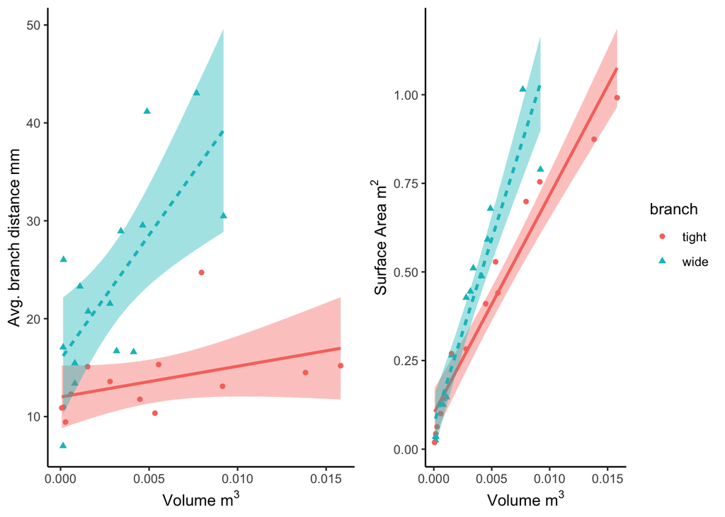

|  | Tight branching avg. distance |  |  | Wide branching avg. distance |  |  |
| --- | --- | --- | --- | --- | --- | --- |
| Predictors | Estimates | CI | p | Estimates | CI | p |
| Intercept | 12.00 | 8.78 – 15.21 | **<0.001** | 15.83 | 9.71 – 21.96 | **<0.001** |
| Volume | 314.86 | -130.07 – 759.80 | 0.148 | 2543.12 | 1013.11 – 4073.12 | **0.003** |
| Observations | 13 |  |  | 15 |  |  |
| R<sup>2</sup> / R<sup>2</sup> adjusted | 0.181 / 0.106 |  |  | 0.498 / 0.459 |  |  |

[output not shown]

### Visualize invertebrate data

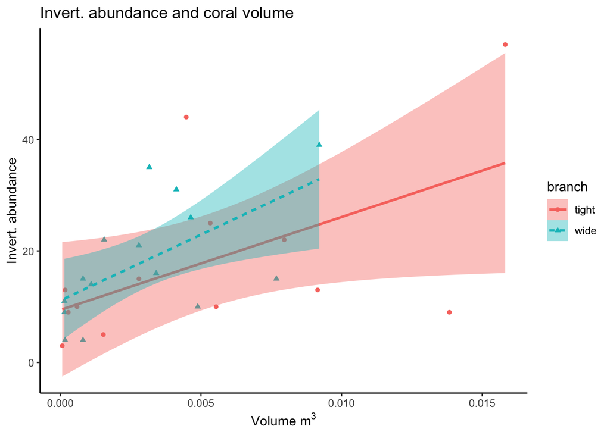

|  | Invert abundance in tight coral |  |  | Invert abundance in wide coral |  |  |
| --- | --- | --- | --- | --- | --- | --- |
| Predictors | Estimates | CI | p | Estimates | CI | p |
| Intercept | 9.42 | -2.71 – 21.55 | 0.115 | 11.10 | 3.76 – 18.45 | **0.006** |
| Volume | 1665.57 | -13.66 – 3344.79 | 0.052 | 2363.29 | 529.60 – 4196.99 | **0.015** |
| Observations | 13 |  |  | 15 |  |  |
| R<sup>2</sup> / R<sup>2</sup> adjusted | 0.302 / 0.239 |  |  | 0.374 / 0.325 |  |  |

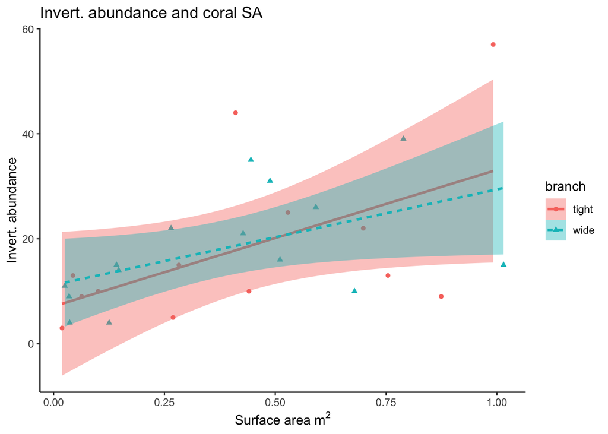

|  | Invert abundance in tight coral |  |  | Invert abundance in wide coral |  |  |
| --- | --- | --- | --- | --- | --- | --- |
| Predictors | Estimates | CI | p | Estimates | CI | p |
| Intercept | 7.12 | -6.96 – 21.21 | 0.290 | 11.19 | 2.46 – 19.91 | **0.016** |
| SA | 26.00 | -0.71 – 52.72 | 0.055 | 18.21 | 0.08 – 36.34 | **0.049** |
| Observations | 13 |  |  | 15 |  |  |
| R<sup>2</sup> / R<sup>2</sup> adjusted | 0.294 / 0.230 |  |  | 0.266 / 0.209 |  |  |

##### Looking at the table relating invertebrate abundance to surface area, we can conclude that the slope for surface area and wide corals is significantly different from zero. There is a weak correlation for surface area and invertebrate abundance for wide and tight corals.

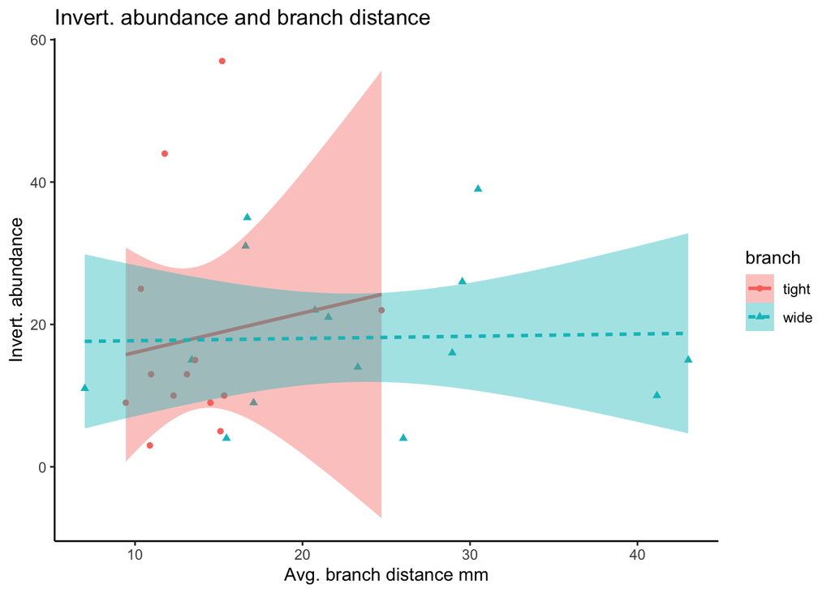

|  | Invert abundance in tight coral |  |  | Invert abundance in wide coral |  |  |
| --- | --- | --- | --- | --- | --- | --- |
| Predictors | Estimates | CI | p | Estimates | CI | p |
| Intercept | 10.53 | -27.47 – 48.53 | 0.554 | 17.40 | 1.13 – 33.67 | **0.038** |
| Avg. branch width | 0.55 | -2.14 – 3.24 | 0.659 | 0.03 | -0.61 – 0.67 | 0.918 |
| Observations | 13 |  |  | 15 |  |  |
| R<sup>2</sup> / R<sup>2</sup> adjusted | 0.018 / -0.071 |  |  | 0.001 / -0.076 |  |  |

##### Based on our linear regression and table for avg. branch width and invertebrate abundance, we cannot conclude that any of the slopes are significantly different from zero or different from each other. There is no correlation between avg. branch distance and invertebrate abundance.

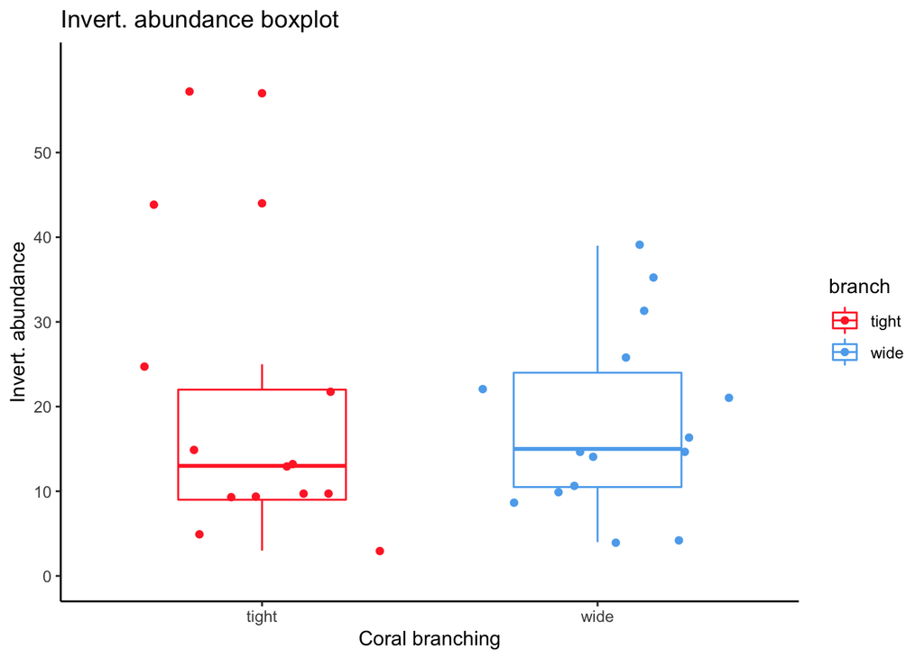

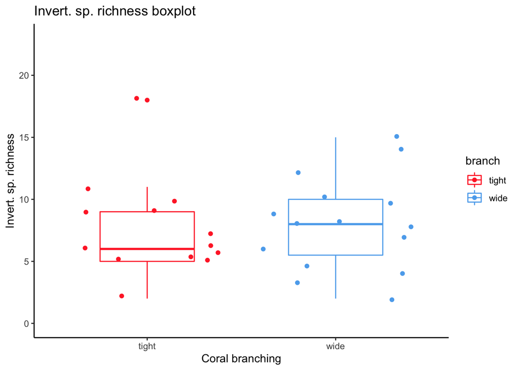

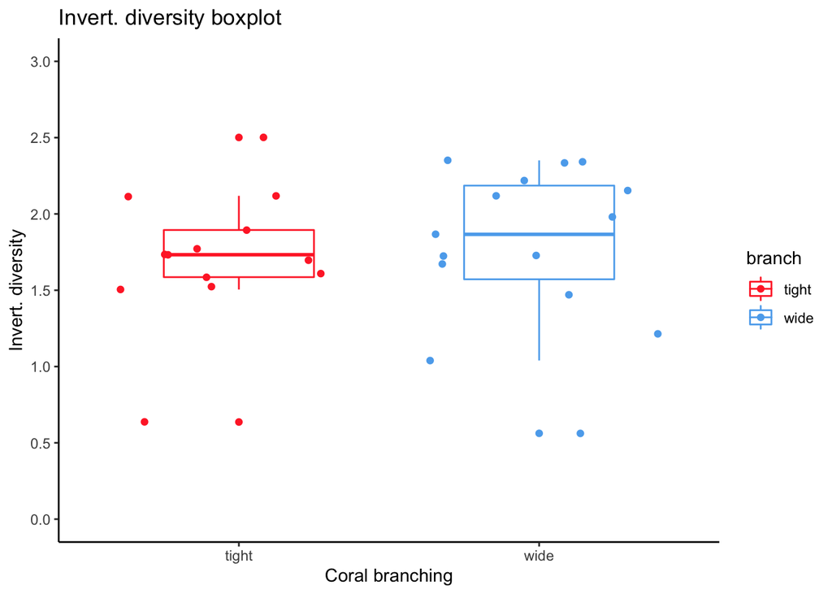

### Visualize Trapezid data

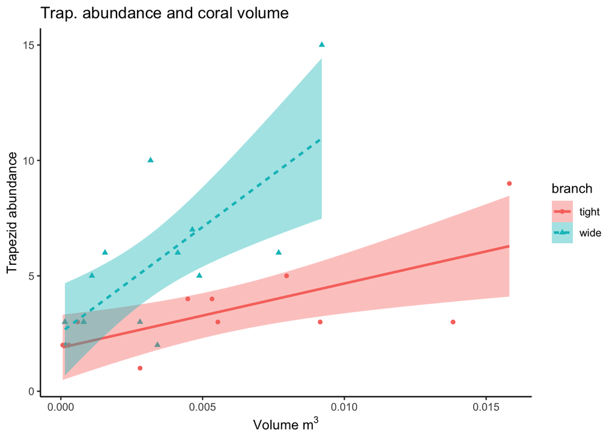

|  | Trap. abundance in tight coral |  |  | Trap abundance in wide coral |  |  |
| --- | --- | --- | --- | --- | --- | --- |
| Predictors | Estimates | CI | p | Estimates | CI | p |
| Intercept | 1.89 | 0.46 – 3.31 | **0.015** | 2.55 | 0.50 – 4.60 | **0.019** |
| Volume | 278.16 | 88.33 – 467.98 | **0.009** | 913.65 | 400.91 – 1426.40 | **0.002** |
| Observations | 12 |  |  | 15 |  |  |
| R<sup>2</sup> / R<sup>2</sup> adjusted | 0.516 / 0.468 |  |  | 0.533 / 0.497 |  |  |

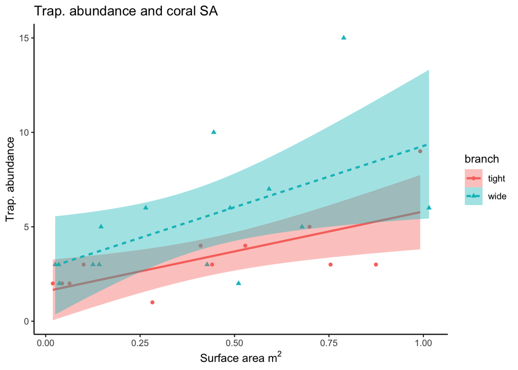

|  | Invert abundance in tight coral |  |  | Invert abundance in wide coral |  |  |
| --- | --- | --- | --- | --- | --- | --- |
| Predictors | Estimates | CI | p | Estimates | CI | p |
| Intercept | 1.58 | -0.07 – 3.24 | 0.059 | 2.79 | 0.08 – 5.50 | **0.045** |
| SA | 4.23 | 1.18 – 7.27 | **0.011** | 6.49 | 0.85 – 12.13 | **0.027** |
| Observations | 12 |  |  | 15 |  |  |
| R<sup>2</sup> / R<sup>2</sup> adjusted | 0.489 / 0.438 |  |  | 0.323 / 0.270 |  |  |

##### Both linear regression slopes are significantly different from zero for both tight and wide corals. Confidence intervals overlap and further tests will have to be conducted to confirm if the slopes are signficantly different from eachother. There is a stronger correlation for SA and tight corals than for wide corals.

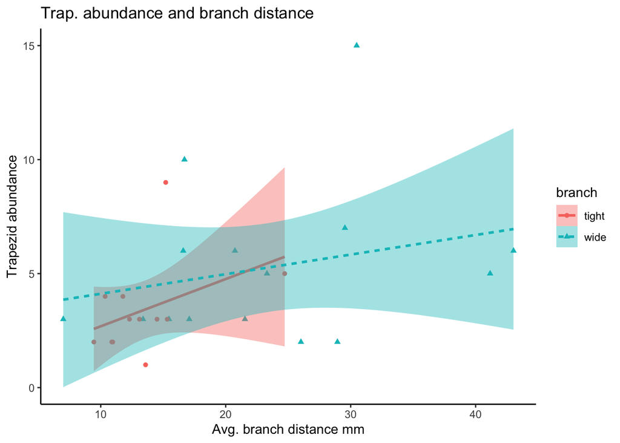

|  | Trap. abundance in tight coral |  |  | Trap abundance in wide coral |  |  |
| --- | --- | --- | --- | --- | --- | --- |
| Predictors | Estimates | CI | p | Estimates | CI | p |
| Intercept | 0.62 | -4.04 – 5.28 | 0.774 | 3.26 | -1.85 – 8.36 | 0.192 |
| Avg. branch distance | 0.21 | -0.12 – 0.54 | 0.194 | 0.09 | -0.12 – 0.29 | 0.374 |
| Observations | 12 |  |  | 15 |  |  |
| R<sup>2</sup> / R<sup>2</sup> adjusted | 0.162 / 0.078 |  |  | 0.061 / -0.011 |  |  |

##### There is no significant difference from zero for the linear regression line slopes and they are not signficantly different from eachother. There is extremely weak correlation for avg. branch distance and Trapezid abundance for both tight and wide corals.

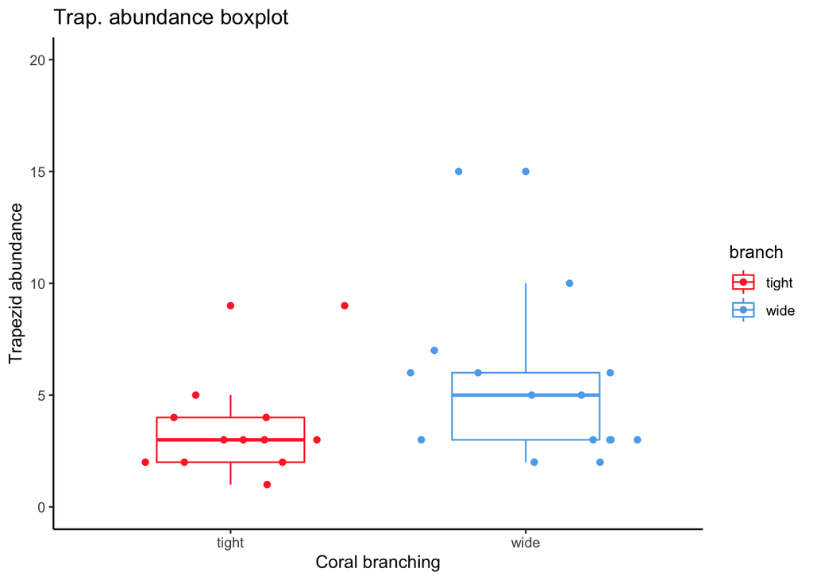

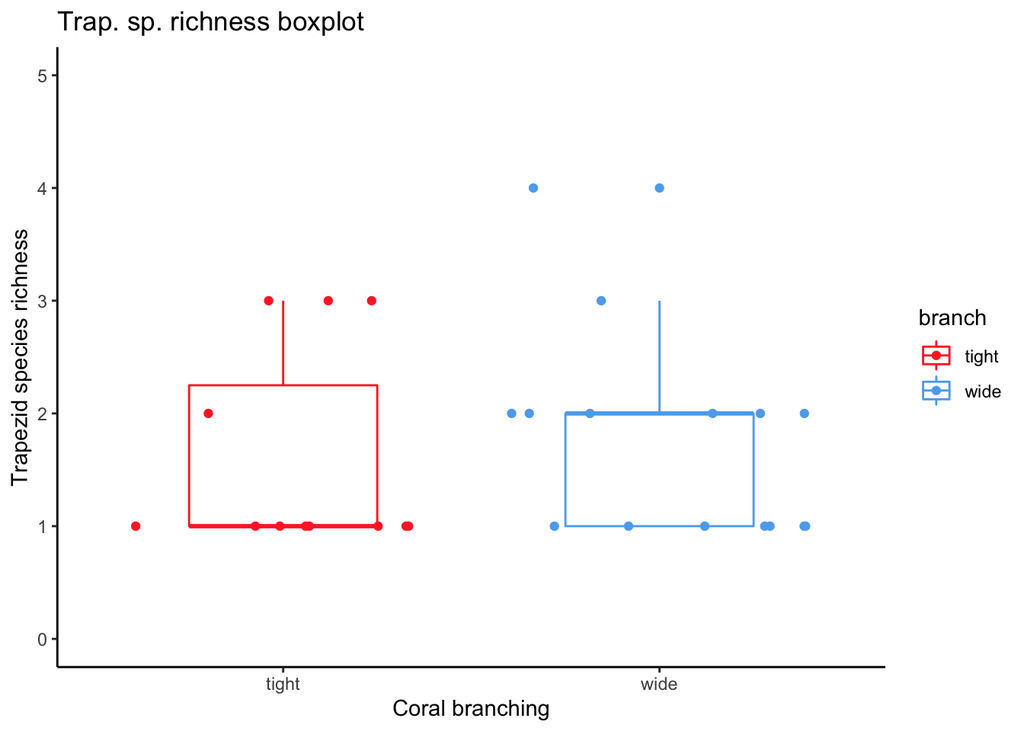

### Visualize Alpheus shrimp data

##### There were not enough data points for Alepheus shrimp and we could not make predictions for shrimp abundance based on the high degree of scatter. Plots were included as a visual representation but will not be analyzed. We will wait for more species to be identified and further data cleaning.

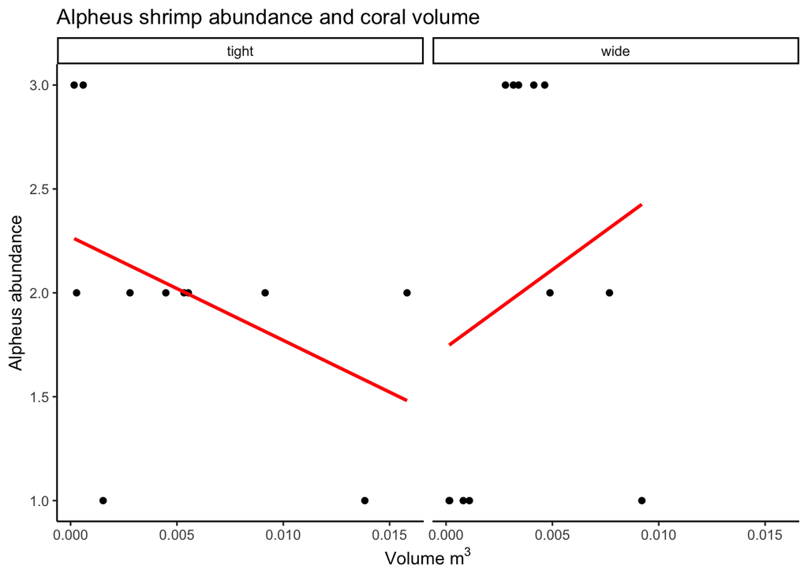

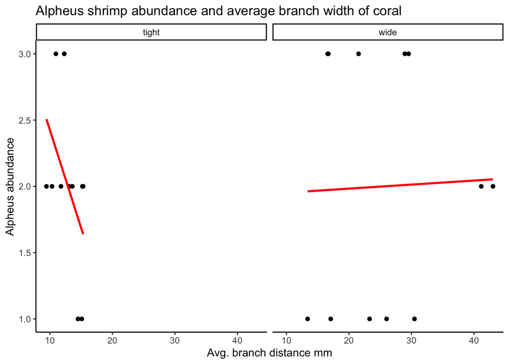

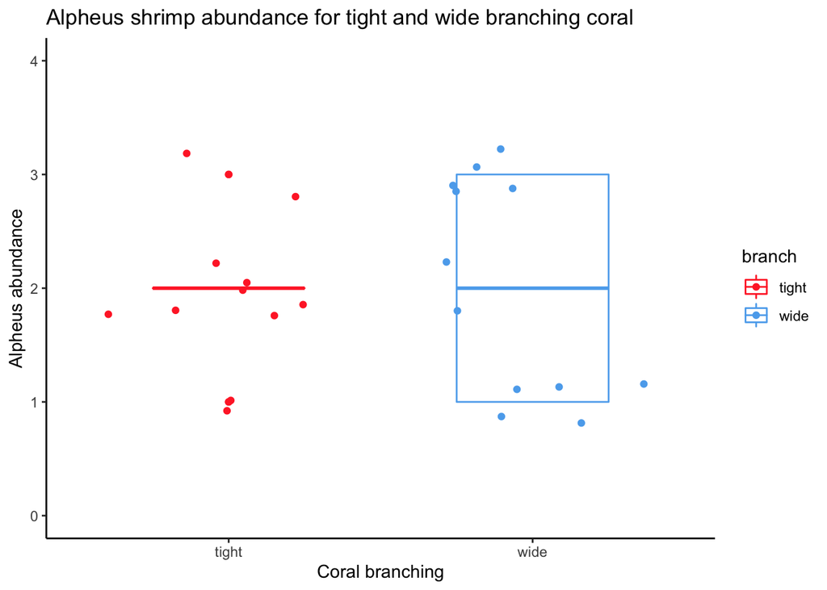

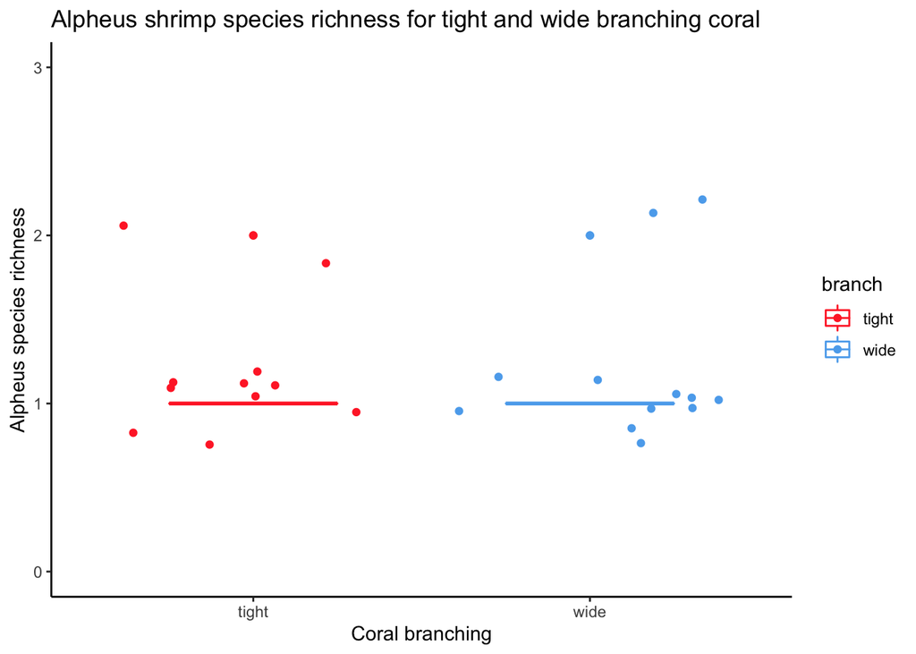